# R2b — Verità manuale per densità nucleare: due annotatori umani, tre segmentatori, tre VLM

geo_spatialtrans · binario R · sessione R2b (2026-09-21 → 2026-09-25)

Author

Claude (esecuzione), Luca Vedovelli (annotatore primario, approvazioni), Federica Pezzuto (secondo annotatore)

Published

October 7, 2026

**Note**

**Verdetto in una riga.** La densità nucleare manuale (Luca, 2 230 nuclei su 24 finestre; Federica, 1 106 su 12) conferma l’ordinamento R2 ma smentisce il “consenso” R2 come stima puntuale: in A2, A3, A4 e A6 gli umani stanno **sopra entrambi** i segmentatori (B-R2b.1 FAIL), il consenso sbaglia fino al 30 % (B-R2b.2 FAIL) e il 13–29 % dei nuclei umani è perso da Cellpose **e** StarDist (CP-R2b.2 FAIL). La controprova proposta da Luca (CP-R2b.5) mostra che quei nuclei persi sono **più pallidi** (OD ematossilina 18–60 % degli appaiati) ma sopra il fondo: una classe ambigua reale. I due umani concordano sul conteggio (2.3 % sul totale; 6/12 finestre entro il 10 %) ma non sulla posizione (F1 a 3 µm 0.76, soglia 0.90 FAIL). `BIO_REFERENCES` v2 riporta quindi la densità come **intervallo** [nuclei evidenti, nuclei totali] con fonte manuale. I VLM: GPT-6 Astra localizza ma sovraconta (10–47 %); deepseek-flash non è un annotatore. Stato: **chiusa con riserve**.

# 1. Pre-registrazione

Testo integrale, con le aggiunte datate, in `results/R2b/R2b_preregistration.md`. Approvazione di Luca: «procedi» (2026-09-21), poi «La strategia resta 2 umani ma aggiungiamo anche uno o due modelli» (2026-09-21).

**Obiettivo unico.** Verità manuale (punti) su finestre campionate dai 30 ROI R2, per archetipo A1–A6, per (a) fissare le righe di densità di `docs/BIO_REFERENCES.md` (chiudere il “provvisorio”, BL-024/BL-030) e (b) misurare recall/precisione di Cellpose-SAM RGB, StarDist HE e Space Ranger 4 per archetipo e scegliere il segmentatore per R3 (BL-032, BL-033).

**Disegno.** Finestre quadrate a lato adattato alla densità (A1 100 µm, A2 120, A3 150, A4 60, A5 250, A6 250; bersaglio 70–110 nuclei), 4 per archetipo su 4 ROI distinti (seed 20260921), tessuto ≥ 90 %, 0 % bolle. Annotazione **alla cieca** con annotatore HTML autonomo. Deviazione dichiarata dalla ROADMAP («100×100 µm»): a 100 µm A5/A6 avrebbero ~10 nuclei per finestra.

**Modifiche di metodo dichiarate prima dei dati** (tutte in pre-registrazione): (1) annotatore v1.1 **solo conteggio** su richiesta di Luca («la complessità introduce errore»): niente contorni, niente giudizio «fuori archetipo» in corso di conteggio; esclusione «illeggibile» solo in A6; (2) il giudizio di omogeneità spostato a una checklist separata per la patologa; (3) area nucleare (B-R2b.5) rinviata a una fase 2 non eseguita; (4) **annotatori automatici** (VLM) aggiunti come rater `model:*` con prompt fissato; (5) **CP-R2b.4** (nullo dei punti casuali) aggiunta dopo l’import del primo VLM, prima dei dati umani; (6) **CP-R2b.5** (stratificazione per evidenza di ematossilina) aggiunta dopo il conteggio di Luca, prima del calcolo, su sua obiezione.

| id | Attesa | Soglia |
| --- | --- | --- |
| C-R2b.1 | finestre dentro ROI/tessuto, coordinate ricostruite | tessuto ≥ 0.90, bolle = 0, round-trip pixel-identico |
| C-R2b.2 | round-trip dell’annotatore | < 0.5 px |
| C-R2b.3 | appaiamento su sintetico | recall/precisione entro 1 % |
| C-R2b.4 | riproducibilità del campionamento | md5 identici |
| B-R2b.1 | manuale fra Cellpose e StarDist (±10 %) | 6/6 |
| B-R2b.2 | consenso R2 vicino al manuale | ±15 % A1–A4, ±20 % A5–A6 |
| B-R2b.3 | direzioni recall (CP>SD A1–A3; SD>CP A5–A6; A4 ≥ 0.85); precisione CP < 0.85 (A5), < 0.70 (A6) | come scritto |
| B-R2b.4 | ordinamento | A4 > A1 > A2 > A3 > A5 > A6 |
| B-R2b.5 | area nucleare manuale | non eseguita (fase 2) |
| CP-R2b.1 | accordo umano Luca–Federica | Δ conteggio < 10 %; F1 (3 µm) > 0.90 |
| CP-R2b.2 | punti umani persi da CP **e** SD | < 5 % |
| CP-R2b.3 | oggetti Cellpose senza punto umano | ≥ 15 % A5, ≥ 30 % A6 |
| CP-R2b.4 | F1 vs nullo punti casuali | > nullo + 0.20 |
| CP-R2b.5 | OD dei persi vs appaiati | ≤ 75 % in ≥ 5/6 |
| VLM-1/2 | GPT-6 Astra errore < 20 %; F1 VLM < 0.6 | come scritto |

# 2. Check C — correttezza software

| id | check | esito | dettaglio |
| --- | --- | --- | --- |
| C-R2b.1a | 24 finestre dentro ROI, tessuto >= 0.90, round-trip pixel-identico | PASS | 24/24 |
| C-R2b.1b | bolle = 0 secondo la maschera R2 (BL-026, parziale): l’annotatore ha escluso bolle in 3 finestre | WARN | maschera R2 0 % in 24/24; esclusioni manuali: A6_w2 1.2%, A6_w3 1.9%, A6_w4 4.9% (revisore avversariale, discrepanza 1) |
| C-R2b.2 | core annotatore (node): round-trip schermo/immagine, zoom, export/import < 0.5 px | PASS | ALL PASS |
| C-R2b.3 | appaiamento su dati sintetici: recall/precisione entro 1 %, 1:1, esclusioni, area | PASS | 10/10 |
| C-R2b.4 | riproducibilita’ campionamento finestre (md5 identici con lo stesso seed) | PASS | 24/24 |
| C-R2b.5 | annotazioni umane importate: Luca 24 finestre, Federica 12 | PASS | Luca 2230 punti, Federica 1106 punti |

Le 24 finestre (`R2b_windows.csv`): una per ROI, 4 ROI su 5 per archetipo; tessuto valido 0.92–1.00; ritaglio dal ROI pixel-identico al ritaglio letto dall’immagine intera alle coordinate ricostruite. Il nucleo geometrico dell’annotatore (`tools/R2b_annotator_core.js`) è testato con node (12 asserzioni); l’appaiamento (`tools/R2b_match.py`) con 10 asserzioni su dati sintetici (recall/precisione noti, assegnazione 1:1, esclusioni, area). Comando unico: `bash R/testing/test_R2b.sh`.

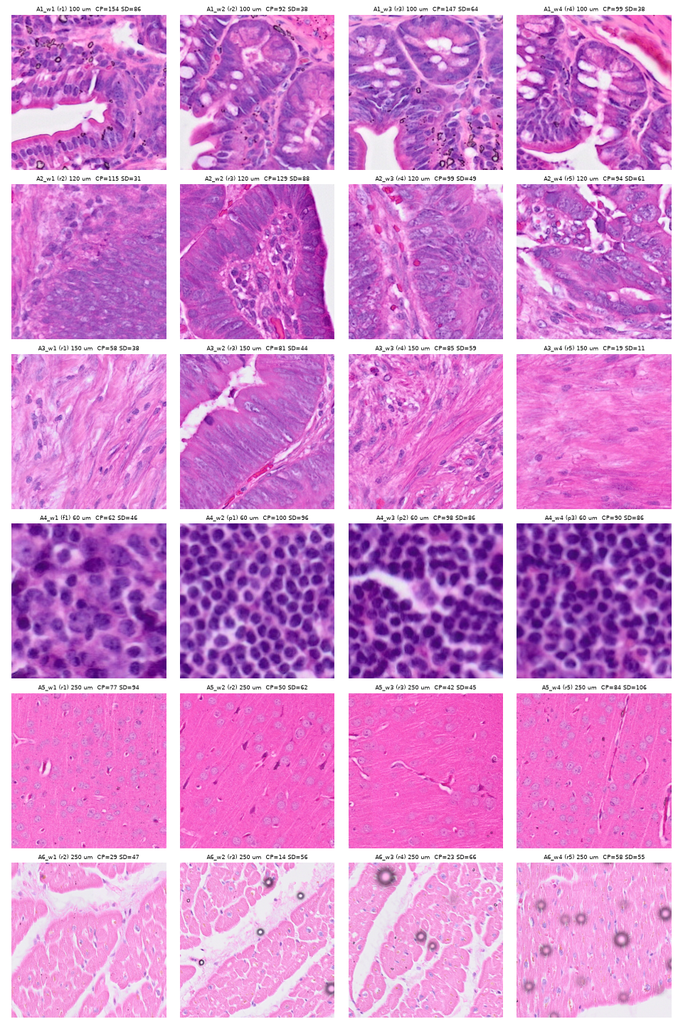

Le 24 finestre (righe A1→A6, colonne w1→w4) con i conteggi Cellpose/StarDist di R2 nel titolo.

# 3. Check B — plausibilità biologica

## 3.1 Densità nucleare: umani vs segmentatori vs R2

Densità nucleare (nuclei/mm² di tessuto netto) sulle stesse finestre. ‘Evidenti’ = punti di Luca appaiati da almeno un segmentatore.

| Archetipo | n Luca | Manuale Luca (IC 95 %) | Evidenti (appaiati ≥1 metodo) | Federica (12 fin.) | Luca (stesse 12) | Cellpose | StarDist | Space Ranger | Consenso R2 (5 ROI) | Consenso/Luca |
| --- | --- | --- | --- | --- | --- | --- | --- | --- | --- | --- |
| A1 | 496 | 12 419 (11 350–13 562) | 10 291 | 13 371 | 12 970 | 12 319 | 5 659 | — | 10 981 | -12 % |
| A2 | 513 | 8 924 (8 168–9 731) | 7 376 | 8 072 | 8 385 | 7 602 | 3 984 | 7 845 | 6 781 | -24 % |
| A3 | 279 | 3 100 (2 747–3 486) | 2 311 | 3 067 | 3 067 | 2 700 | 1 689 | 2 289 | 4 016 | +30 % |
| A4 | 404 | 28 096 (25 423–30 974) | 26 844 | 27 957 | 31 851 | 24 341 | 21 837 | 29 000 | 23 247 | -17 % |
| A5 | 296 | 1 185 (1 054–1 328) | 953 | 1 185 | 1 073 | 1 013 | 1 229 | 809 | 1 365 | +15 % |
| A6 | 242 | 988 (867–1 121) | 906 | 960 | 1 085 | 486 | 825 | 1 078 | 1 078 | +9 % |

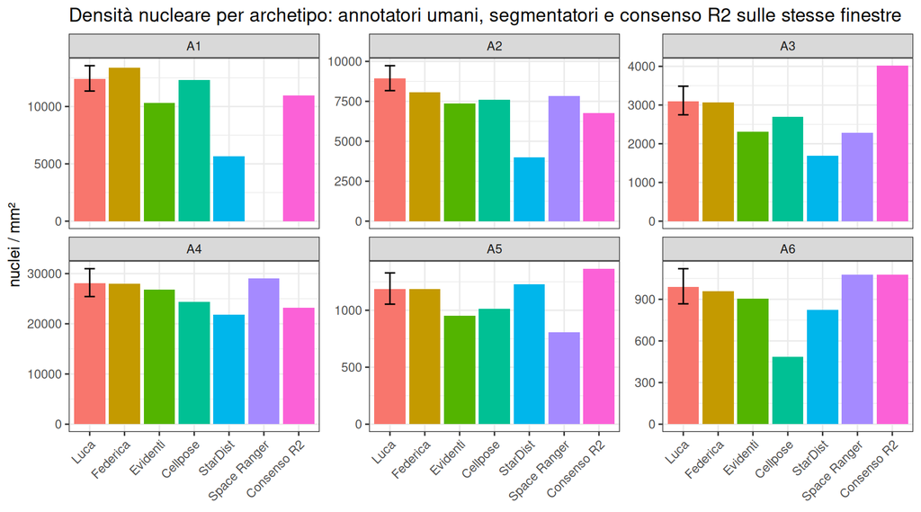

### Robustezza del confronto con R2 (rilievi R1–R3 del revisore, accolti)

Tre letture alternative dello scarto manuale–consenso R2.

| Archetipo | Luca / area netta | Luca / area tessuto | IC t 95 % fra le 4 finestre | Consenso R2, 5 ROI | Consenso R2, 4 ROI campionati | Δ vs 5 ROI | Δ vs ROI campionati (denominatore tessuto) |
| --- | --- | --- | --- | --- | --- | --- | --- |
| A1 | 12 419 | 12 643 | 7 103–17 735 | 10 981 | 11 022 | -12 % | -13 % |
| A2 | 8 924 | 9 021 | 7 090–10 758 | 6 781 | 6 419 | -24 % | -29 % |
| A3 | 3 100 | 3 100 | 1 096–5 105 | 4 016 | 4 219 | +30 % | +36 % |
| A4 | 28 096 | 28 096 | 17 893–38 299 | 23 247 | 23 840 | -17 % | -15 % |
| A5 | 1 185 | 1 204 | 555–1 814 | 1 365 | 1 482 | +15 % | +23 % |
| A6 | 988 | 1 052 | 764–1 216 | 1 078 | 1 117 | +9 % | +6 % |

Tre precisazioni dovute al revisore. (R1) L’IC di Poisson tratta i nuclei come indipendenti; la variabilità **fra finestre** è 3–5 volte maggiore (IC t su 4 finestre: A1 7 100–17 700, A4 17 900–38 300): il consenso R2 cade **dentro** l’IC t in 5/6 archetipi e fuori solo in A2 (6 781 < 7 090): con 4 finestre B-R2b.2 ha potenza per bocciare il consenso solo in A2; per gli altri l’evidenza robusta è la direzione sistematica (il consenso sta sotto gli umani in A1, A2, A4 e sopra in A3, A5) e il meccanismo (CP-R2b.5), non il singolo scarto. (R2) Confrontando con i soli 4 ROI campionati: A2 −29 %, A3 +36 %, A4 −15 %, A5 +23 % — B-R2b.2 passerebbe in 2/6, non 3/6. (R3) Il consenso R2 è per mm² di **tessuto**, Luca per mm² di finestra netta (tessuto 0.92–1.00): sull’area tessuto A6 diventa 1 052 /mm² (scarto +6 % anziché +9 %) e A5 1 204.

**A3 senza A3_w2.** La finestra A3_w2 (ROI r3) contiene epitelio ghiandolare tumorale (giudizio di Claude sulla sovrapposizione; la patologa non l’ha valutata, §4.6). Senza di essa: Luca 175 nuclei, **2 593 /mm²** (evidenti 2 060) contro 3 100 con; il consenso R2 (4 016) resta sopra in entrambi i casi. Analogamente **A4_w1 è un follicolo** (18 638 /mm²) contro tre finestre paracorticali (~31 000): il campione R2b ha 1 follicolo su 4 finestre, R2 aveva 2 ROI follicolari su 5 — parte dello scarto A4 (−17 %) è composizione, non segmentazione (rilievo R9).

## 3.2 Recall e precisione dei segmentatori contro gli umani

Recall / precisione per archetipo (appaiamento: punto dentro la maschera, altrimenti centroide ≤ 3 µm, 1:1). Federica solo sulle sue 12 finestre.

| archetype | Federica · cellpose_rgb | Federica · stardist_he | Luca · cellpose_rgb | Luca · stardist_he | Federica · spaceranger | Luca · spaceranger |
| --- | --- | --- | --- | --- | --- | --- |
| A1 | 0.84 / 0.87 | 0.45 / 0.92 | 0.82 / 0.82 | 0.41 / 0.89 | NA | NA |
| A2 | 0.79 / 0.80 | 0.56 / 0.85 | 0.74 / 0.85 | 0.40 / 0.89 | 0.81 / 0.74 | 0.69 / 0.78 |
| A3 | 0.83 / 0.78 | 0.64 / 0.89 | 0.69 / 0.79 | 0.44 / 0.80 | 0.76 / 0.74 | 0.55 / 0.73 |
| A4 | 0.95 / 0.95 | 0.94 / 0.98 | 0.86 / 0.95 | 0.78 / 0.97 | 1.00 / 0.83 | 0.94 / 0.88 |
| A5 | 0.82 / 0.90 | 0.87 / 0.76 | 0.77 / 0.89 | 0.71 / 0.68 | 0.68 / 0.83 | 0.52 / 0.75 |
| A6 | 0.50 / 0.74 | 0.69 / 0.68 | 0.42 / 0.82 | 0.71 / 0.85 | 0.89 / 0.76 | 0.89 / 0.81 |

| id | check | esito | dettaglio |
| --- | --- | --- | --- |
| B-R2b.1 | densita’ manuale fra Cellpose e StarDist (+-10 %) sulle stesse finestre, 6/6 | FAIL | 2/6; sopra entrambi: A2, A3, A4, A6 |
| B-R2b.2 | consenso R2 entro +-15 % (A1-A4) / +-20 % (A5-A6) dalla densita’ manuale | FAIL | 3/6; A1 -12%; A2 -24%; A3 +30%; A4 -17%; A5 +15%; A6 +9% |
| B-R2b.3a | direzione dei richiami: CP>SD in A1-A3, SD>CP in A5-A6, A4 entrambi >= 0.85 | FAIL | A1:ok, A2:ok, A3:ok, A5:NO, A6:ok, A4:NO |
| B-R2b.3b | precisione Cellpose < 0.85 in A5 e < 0.70 in A6 (BL-032/033) | FAIL | A5 0.89, A6 0.82 |
| B-R2b.4 | ordinamento A4 > A1 > A2 > A3 > A5 > A6 | PASS | A4 > A1 > A2 > A3 > A5 > A6 |
| B-R2b.5 | area nucleare da contorni manuali | N/A | fase 2 (calibri) non eseguita in R2b; BL-025 resta aperta |

# 4. Controprove

## 4.1 CP-R2b.1 — accordo inter-annotatore umano

| Finestra | n Luca | n Federica | Fed/Luca | Δ rel. | F1 3 µm | F1 5 µm |
| --- | --- | --- | --- | --- | --- | --- |
| A1_w1 | 162 | 151 | 0.93 | 7 % | 0.86 | 0.89 |
| A1_w4 | 97 | 116 | 1.20 | 18 % | 0.80 | 0.85 |
| A2_w2 | 135 | 133 | 0.99 | 1 % | 0.69 | 0.85 |
| A2_w4 | 106 | 99 | 0.93 | 7 % | 0.68 | 0.81 |
| A3_w1 | 60 | 53 | 0.88 | 12 % | 0.76 | 0.87 |
| A3_w3 | 78 | 85 | 1.09 | 9 % | 0.65 | 0.71 |
| A4_w2 | 118 | 104 | 0.88 | 13 % | 0.89 | 0.89 |
| A4_w4 | 111 | 97 | 0.87 | 13 % | 0.90 | 0.91 |
| A5_w2 | 50 | 54 | 1.08 | 8 % | 0.52 | 0.77 |
| A5_w4 | 84 | 94 | 1.12 | 11 % | 0.64 | 0.79 |
| A6_w3 | 62 | 58 | 0.94 | 7 % | 0.73 | 0.85 |
| A6_w4 | 69 | 62 | 0.90 | 11 % | 0.72 | 0.82 |

Totale: Luca 1132, Federica 1106 (Δ 2.3 %); per archetipo Δ = A1 3 %, A2 4 %, A3 0 %, A4 13 %, A5 10 %, A6 9 %; **6/12 finestre entro il 10 %**. F1 punto-punto 3 µm 0.76, 5 µm 0.84. Esito: **conteggio PASS** (soglia < 10 % sul totale e su 5/6 archetipi; la superano: A4 13 %), **posizione FAIL** (0.76 < 0.90). Le differenze di **densità** sulle 12 finestre comuni (§3.1, colonne Federica / Luca) sono invece −12 % in A4 e −12 % in A6: in A6 lo scarto è maggiore di quello dei conteggi perché la densità di Luca è su area netta (esclusioni delle bolle) e quella di Federica su area lorda (non ha disegnato esclusioni pur dichiarando di aver saltato le bolle). Interpretazione: due umani che contano lo stesso numero cliccano punti diversi soprattutto in A2 e A5; la soglia di 3 µm era pensata per l’appaiamento con maschere, non per due click su nuclei di 6–11 µm. Nessuna direzione sistematica fra i due (Federica > Luca in A1, A5; < in A4, A6). Limite di cecità (rilievo R10): l’annotatore non mostrava alcuna segmentazione, ma Luca aveva visto in chat la tavola delle finestre con i conteggi Cellpose/StarDist nei titoli prima di contare; Federica no. Federica ha dichiarato di aver **saltato le bolle** in A6 (coerente con le esclusioni di Luca) e contato **sia neuroni sia glia** in A5. Non avendo disegnato esclusioni, la sua densità A6 è su area lorda: con l’area netta di Luca sulle stesse due finestre passa da 960 a 994 /mm² (Luca 1 085; divario da −12 % a −8 %).

## 4.3 CP-R2b.5 — i persi sono i pallidi? (tesi di Luca)

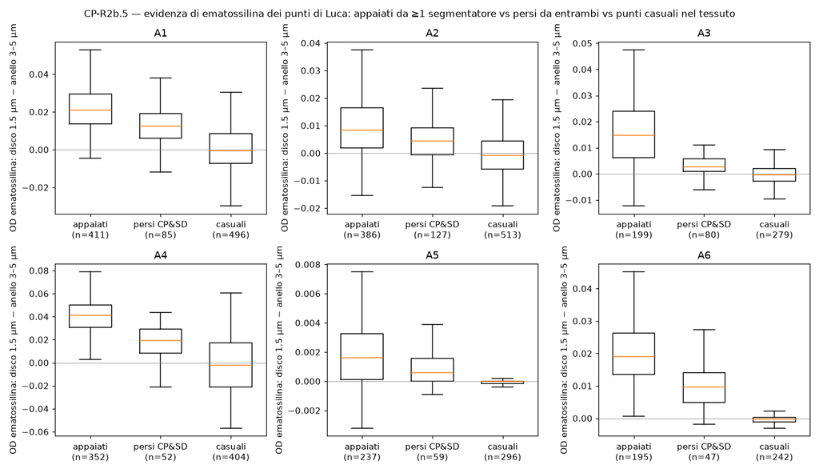

OD ematossilina (disco 1.5 µm − anello 3–5 µm) dei punti di Luca: appaiati da ≥ 1 segmentatore, persi da entrambi, punti casuali nel tessuto.

CP-R2b.5: PASS = OD mediano dei persi ≤ 75 % di quello degli appaiati.

| rater | archetype | n appaiati | n persi | OD appaiati | OD persi | persi/appaiati | persi sopra Q75 del fondo | esito |
| --- | --- | --- | --- | --- | --- | --- | --- | --- |
| Luca | A1 | 411 | 85 | 0.021 | 0.012 | 0.60 | 62 % | PASS |
| Luca | A2 | 386 | 127 | 0.008 | 0.004 | 0.53 | 50 % | PASS |
| Luca | A3 | 199 | 80 | 0.015 | 0.003 | 0.18 | 59 % | PASS |
| Luca | A4 | 352 | 52 | 0.041 | 0.019 | 0.46 | 52 % | PASS |
| Luca | A5 | 237 | 59 | 0.002 | 0.001 | 0.37 | 71 % | PASS |
| Luca | A6 | 195 | 47 | 0.019 | 0.010 | 0.50 | 94 % | PASS |
| Federica | A1 | 227 | 40 | 0.018 | 0.009 | 0.51 | 52 % | PASS |
| Federica | A2 | 190 | 42 | 0.009 | 0.005 | 0.63 | 64 % | PASS |
| Federica | A3 | 118 | 20 | 0.015 | 0.001 | 0.09 | 45 % | PASS |
| Federica | A4 | 194 | 7 | 0.036 | 0.013 | 0.36 | 43 % | PASS |
| Federica | A5 | 139 | 9 | 0.002 | 0.001 | 0.57 | 67 % | PASS |
| Federica | A6 | 101 | 19 | 0.018 | 0.003 | 0.19 | 63 % | PASS |

**PASS 6/6 per entrambi gli annotatori.** I nuclei umani che i segmentatori perdono hanno un’evidenza di ematossilina pari al 18–60 % (Luca) e 9–63 % (Federica) di quella dei nuclei appaiati: sono la classe ambigua. Ma non sono fondo: in 5/6 archetipi oltre la metà di essi supera il 75° percentile dei punti casuali (in A6 il 94 %). Conseguenza dichiarata: la densità di riferimento è un **intervallo** [evidenti, totale].

## 4.4 CP-R2b.3 e CP-R2b.4 — oggetti fantasma e nullo dei punti casuali

CP-R2b.4: N punti uniformi nel tessuto valido (N = punti di Luca), 20 repliche, stesse regole di appaiamento.

| archetype | method | F1 osservato | F1 nullo | precisione oss. | precisione nulla | esito |
| --- | --- | --- | --- | --- | --- | --- |
| A1 | cellpose_rgb | 0.82 | 0.30 | 0.82 | 0.30 | PASS |
| A1 | stardist_he | 0.56 | 0.20 | 0.89 | 0.32 | PASS |
| A2 | cellpose_rgb | 0.78 | 0.29 | 0.85 | 0.31 | PASS |
| A2 | spaceranger | 0.73 | 0.29 | 0.78 | 0.31 | PASS |
| A2 | stardist_he | 0.55 | 0.19 | 0.89 | 0.31 | PASS |
| A3 | cellpose_rgb | 0.73 | 0.16 | 0.79 | 0.17 | PASS |
| A3 | spaceranger | 0.62 | 0.10 | 0.73 | 0.12 | PASS |
| A3 | stardist_he | 0.57 | 0.09 | 0.80 | 0.13 | PASS |
| A4 | cellpose_rgb | 0.88 | 0.49 | 0.95 | 0.52 | PASS |
| A4 | spaceranger | 0.90 | 0.54 | 0.88 | 0.54 | PASS |
| A4 | stardist_he | 0.85 | 0.47 | 0.97 | 0.54 | PASS |
| A5 | cellpose_rgb | 0.82 | 0.10 | 0.89 | 0.11 | PASS |
| A5 | spaceranger | 0.61 | 0.09 | 0.75 | 0.11 | PASS |
| A5 | stardist_he | 0.70 | 0.09 | 0.68 | 0.09 | PASS |
| A6 | cellpose_rgb | 0.54 | 0.03 | 0.82 | 0.05 | PASS |
| A6 | spaceranger | 0.85 | 0.04 | 0.81 | 0.04 | PASS |
| A6 | stardist_he | 0.77 | 0.03 | 0.85 | 0.04 | PASS |

## 4.5 Annotatori automatici (VLM)

| archetype | modello | n/n Luca | \|err\| mediano | F1 vs Luca 3 µm | 5 µm | guadagno F1 sul nullo (Cellpose) |
| --- | --- | --- | --- | --- | --- | --- |
| A1 | deepseek_flash_nothink | 0.84 | 24 % | 0.33 | 0.49 | 0.05 |
| A1 | deepseek_flash_think | 1.41 | 41 % | 0.37 | 0.62 | 0.05 |
| A1 | gpt6_astra | 1.29 | 41 % | 0.67 | 0.78 | 0.36 |
| A2 | deepseek_flash_nothink | 0.64 | 47 % | 0.16 | 0.40 | 0.02 |
| A2 | deepseek_flash_think | 1.34 | 35 % | 0.26 | 0.53 | 0.06 |
| A2 | gpt6_astra | 1.13 | 16 % | 0.52 | 0.70 | 0.30 |
| A3 | deepseek_flash_nothink | 0.81 | 27 % | 0.11 | 0.23 | 0.02 |
| A3 | deepseek_flash_think | 1.24 | 62 % | 0.11 | 0.28 | 0.03 |
| A3 | gpt6_astra | 1.47 | 27 % | 0.43 | 0.59 | 0.38 |
| A4 | deepseek_flash_nothink | 1.43 | 40 % | 0.70 | 0.79 | 0.16 |
| A4 | deepseek_flash_think | 1.72 | 62 % | 0.64 | 0.73 | 0.11 |
| A4 | gpt6_astra | 1.10 | 10 % | 0.85 | 0.92 | 0.34 |
| A5 | deepseek_flash_nothink | 1.16 | 15 % | 0.08 | 0.18 | 0.09 |
| A5 | deepseek_flash_think | 2.47 | 135 % | 0.07 | 0.16 | 0.03 |
| A5 | gpt6_astra | 1.42 | 46 % | 0.51 | 0.60 | 0.53 |
| A6 | deepseek_flash_nothink | 1.14 | 13 % | 0.05 | 0.12 | 0.03 |
| A6 | deepseek_flash_think | 3.10 | 207 % | 0.03 | 0.10 | -0.01 |
| A6 | gpt6_astra | 1.25 | 20 % | 0.67 | 0.76 | 0.42 |

GPT-6 Astra (24 finestre, eseguito da Luca con il prompt fissato; versione e data da registrare) sovraconta del 10–47 % (VLM-1 FAIL 4/6) ma localizza (F1 5 µm 0.59–0.92; guadagno sul nullo 0.29–0.53). deepseek-flash (API, `tools/R2b_run_vlm.py`, temperature 0): in modalità thinking sovraconta fino a ×3 e non è ripetibile (due corse sulla stessa immagine differiscono in mediana del 40 %, max ×3.1; tabella `annotations_raw/deepseek_flash_think/repeatability_pairs.csv`); senza thinking produce conteggi ricorrenti (68 in 10 finestre su 24) con posizioni al livello del nullo (guadagno ≈ 0.03). **Nessun VLM è un annotatore utilizzabile per la posizione; nessuno batte i segmentatori dedicati**, salvo GPT-6 Astra in A6 (F1 0.76 vs Cellpose 0.54). Deviazione: la doppia corsa parallela di DeepSeek-thinking su 21 finestre è un errore di procedura, convertito in misura di ripetibilità; il file usato nelle tabelle è la seconda risposta.

## 4.6 Omogeneità delle finestre (checklist della patologa)

Federica ha compilato la checklist (`R2b_checklist_Federica.csv`): 12 finestre giudicate **omogenee** (A1_w1, A1_w4, A2_w3, A2_w4, A3_w1, A3_w3, A4_w2, A4_w3, A5_w2, A5_w3, A6_w3, A6_w4), 12 non valutate, nessun «no». Le 12 valutate non coincidono esattamente con le 12 contate (A2_w3, A4_w3, A5_w3 al posto di w2/w4/w4): probabile sfasamento di riga. **A3_w2 non è stata valutata**: il giudizio «epitelio ghiandolare tumorale» resta di Claude (sovrapposizione in §4.7) e A3 è riportato con e senza (§3.1). Va in BACKLOG.

## 4.7 Sovrapposizioni

Rosso = punto di Luca appaiato ad almeno un segmentatore; triangolo giallo = perso da Cellpose e StarDist; verde = contorni Cellpose; blu = StarDist; arancio = esclusioni di Luca (bolle). Tutte le 24 in `results/R2b/figures/overlay_*.png`.

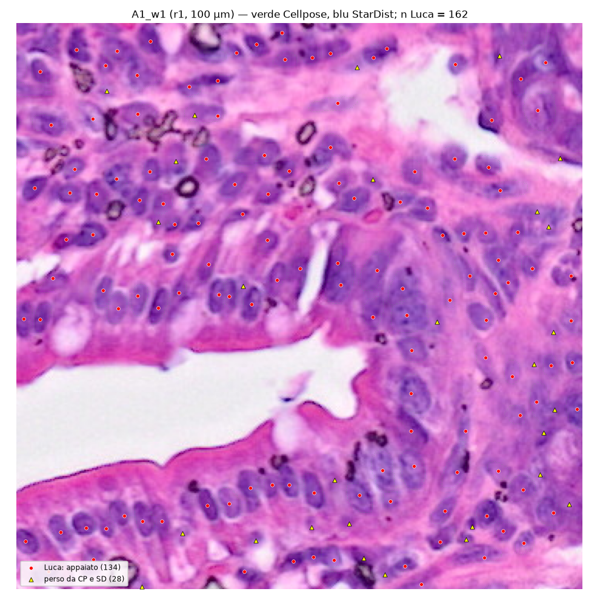

A1_w1 — mucosa: persi nella lamina propria e nuclei pallidi epiteliali

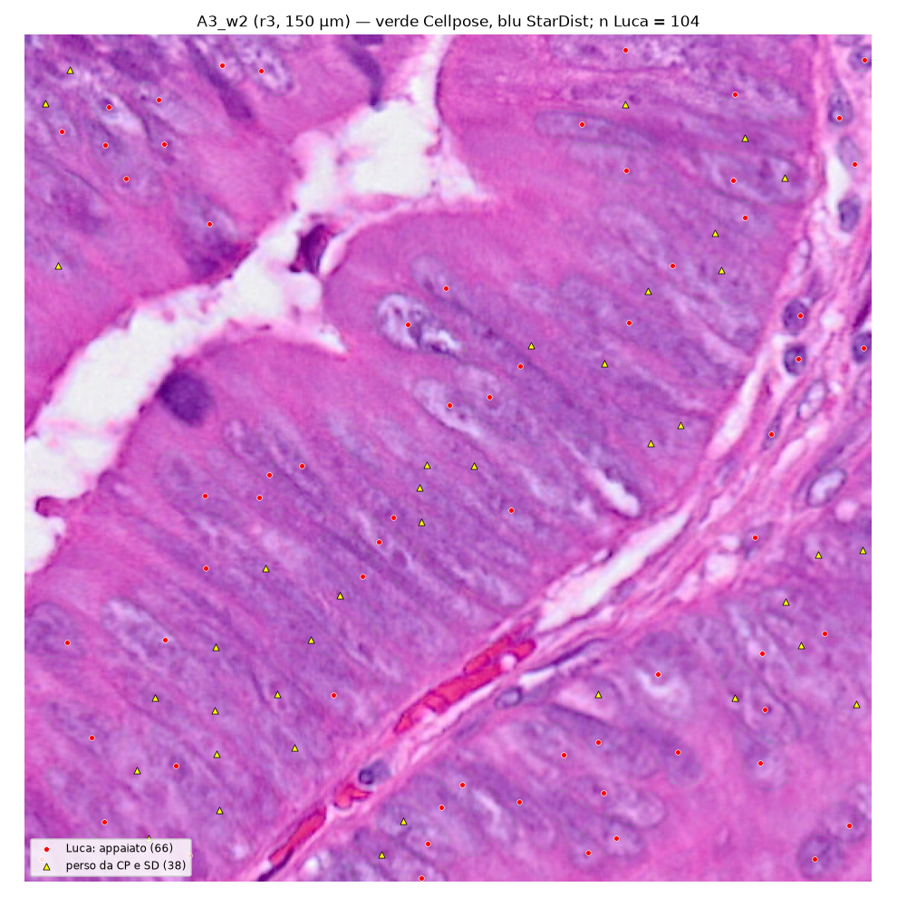

A3_w2 — epitelio ghiandolare tumorale, non stroma (fuori archetipo)

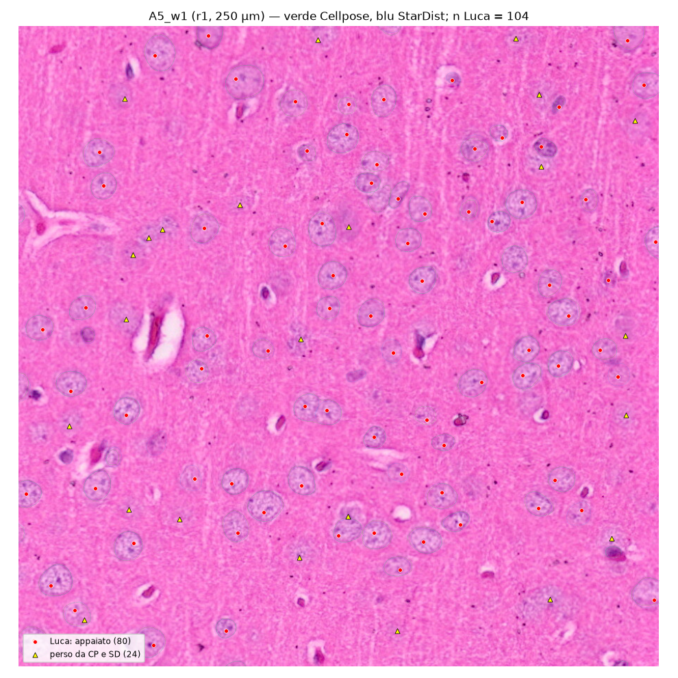

A5_w1 — persi: nuclei gliali piccoli fra i somi pallidi

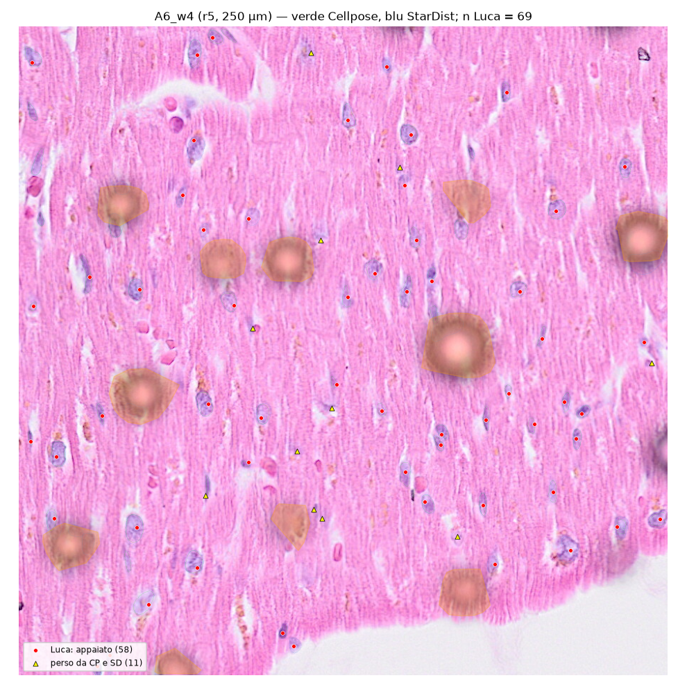

A6_w4 — esclusioni (bolle) e nuclei allungati dei cardiomiociti

# 5. Verdetto

| id | check | esito | dettaglio |
| --- | --- | --- | --- |
| B-R2b.1 | densita’ manuale fra Cellpose e StarDist (+-10 %) sulle stesse finestre, 6/6 | FAIL | 2/6; sopra entrambi: A2, A3, A4, A6 |
| B-R2b.2 | consenso R2 entro +-15 % (A1-A4) / +-20 % (A5-A6) dalla densita’ manuale | FAIL | 3/6; A1 -12%; A2 -24%; A3 +30%; A4 -17%; A5 +15%; A6 +9% |
| B-R2b.3a | direzione dei richiami: CP>SD in A1-A3, SD>CP in A5-A6, A4 entrambi >= 0.85 | FAIL | A1:ok, A2:ok, A3:ok, A5:NO, A6:ok, A4:NO |
| B-R2b.3b | precisione Cellpose < 0.85 in A5 e < 0.70 in A6 (BL-032/033) | FAIL | A5 0.89, A6 0.82 |
| B-R2b.4 | ordinamento A4 > A1 > A2 > A3 > A5 > A6 | PASS | A4 > A1 > A2 > A3 > A5 > A6 |
| B-R2b.5 | area nucleare da contorni manuali | N/A | fase 2 (calibri) non eseguita in R2b; BL-025 resta aperta |
| CP-R2b.1a | accordo umano Luca-Federica: differenza relativa di conteggio < 10 % | WARN | totale 2.3% (PASS); per archetipo 5/6 (max 13% A4); per finestra 6/12: PASS solo sul totale (revisore, R5) |
| CP-R2b.1b | accordo umano: F1 punto-punto (3 um) > 0.90 | FAIL | F1 3 um 0.76; 5 um 0.84 |
| CP-R2b.2 | punti manuali persi da entrambi CP e SD < 5 % per archetipo | FAIL | A1 17%; A2 25%; A3 29%; A4 13%; A5 20%; A6 19% |
| CP-R2b.3 | oggetti Cellpose senza punto manuale: >= 15 % in A5, >= 30 % in A6 (BL-032/033) | FAIL | A5 11% (nullo 89%), A6 18% (nullo 95%) |
| CP-R2b.4 | nullo punti casuali: F1 Luca > F1 nullo + 0.20 per archetipo e metodo | PASS | min guadagno 0.36; 17/17 |
| CP-R2b.4m | VLM vs nullo (misura, nessuna attesa) | INFO | deepseek_flash_nothink mediana 0.03; deepseek_flash_think mediana 0.03; gpt6_astra mediana 0.36 |
| CP-R2b.5 | OD ematossilina dei punti persi da CP e SD <= 75 % degli appaiati in >= 5/6 (Luca) — tesi di Luca | PASS | Luca 6/6 (rapporti 0.60, 0.53, 0.18, 0.46, 0.37, 0.50); Federica 6/6 |
| VLM-1 | GPT-6 Astra: errore relativo di conteggio mediano < 20 % per archetipo | FAIL | 2/6; A1 41%; A2 16%; A3 27%; A4 10%; A5 46%; A6 20% |
| VLM-2 | VLM: F1 punto-punto (3 um) vs Luca atteso < 0.6 | FAIL | deepseek_flash_nothink 0.29; deepseek_flash_think 0.28; gpt6_astra 0.61 |

# 6. Revisione avversariale

| # | Rilievo | Esito |
| --- | --- | --- |
| D1 | «bolle = 0» in C-R2b.1 è un falso positivo: la maschera bolle R2 (BL-026) non vede le bolle sfocate che Luca ha escluso in A6_w2/w3/w4 | **accolto** → C-R2b.1b WARN; BL-040 |
| D2 | `deepseek_flash_think` A6_w3: 0 punti ma n_manual 242 | **spiegato**: il modello ha restituito `n_nuclei` senza posizioni; per disegno il conteggio dichiarato entra in `manual_windows` (count_only = TRUE) e la finestra è esclusa dall’appaiamento; documenta… |
| D3 | Space Ranger: ±1–2 oggetti in A4_w2/w3/w4, A6_w2 fra `R2b_windows.csv` e `matching` | **accolto come nota**: centroidi da parquet R2 vs da label image rasterizzata (poligoni SR non connessi); < 2 % |
| R1 | IC Poisson sottostima di 3–5× la varianza fra finestre; B-R2b.2 senza potenza | **accolto con precisazione** → §3.1 robustezza; BIO_REFERENCES riporta anche l’IC t. Il revisore scriveva «tutti gli scarti cadono dentro»: in A2 il consenso (6 781) sta sotto l’IC t (7 090–10 758), q… |
| R2 | confronto con i 5 ROI anziché i 4 campionati | **accolto** → §3.1 (2/6 anziché 3/6) |
| R3 | denominatori diversi (finestra netta vs tessuto) | **accolto** → §3.1 |
| R4 | «l’appaiamento non è 1:1» (tp_points > tp) | **respinto con verifica**: 0 oggetti con due punti; i 30 punti in più sono appaiati a oggetti di bordo (centroide fuori finestra entro il margine di 10 µm); la sotto-segmentazione resta visibile come … |
| R5 | CP-R2b.1a PASS solo sul totale pooled | **accolto** → WARN (6/12 finestre, 4/6 archetipi) |
| R6 | bias a favore delle maschere grandi; precisione da leggere contro il nullo | **accolto**: già così in §4.4; aggiunta la nota sul diametro implicato (Cellpose A5 11.6 µm vs StarDist 9.5) |
| R7 | scala OD piccola; «più pallidi» non prova che siano nuclei | **accolto in parte**: la scala è quella di `rgb2hed`; il report già dice «classe ambigua, non fondo» |
| R9 | A3_w2 e A4_w1 non rappresentative | **accolto** → §3.1; BL-036 |
| R10 | cecità dell’annotatore primario non totale (tavola con conteggi vista in chat) | **accolto** → §4.1 |
| R11 | identità di Federica assegnata post hoc; VLM-2 GPT-6 al limite (0.59 mediana / 0.61 pooled) | **accolto come nota** (dichiarato nel JSON e nella nota di sessione) |

Ricalcolo indipendente (estratto; note complete nel CSV).

| n | claim | declared | recomputed | result |
| --- | --- | --- | --- | --- |
| 1 | Conteggio punti JSON: Luca 2230 su 24 finestre, Federica 1106 su 12 | Luca 2230; Federica 1106 | Luca 2230/2230 in finestra (24 w); Federica 1106 in finestra su 1107 punti esportati (12 w); GPT-6 2800/2800 | CONFERMATA |
| 2 | Densita’ manuale Luca per archetipo (n/area netta) e IC Poisson A1 | A1 12419, A2 8924, A3 3100, A4 28096, A5 1185, A6 988; IC A1 11350-13562 | A1 12419.2, A2 8923.9, A3 3100.5, A4 28096.1, A5 1184.9, A6 987.9; IC Poisson esatto A1 11350.1-13561.8 | CONFERMATA |
| 3 | Ordinamento manuale A4 > A1 > A2 > A3 > A5 > A6 | PASS | 28096 > 12419 > 8924 > 3100 > 1185 > 988 | CONFERMATA |
| 4 | Consenso R2 (media 5 ROI)/Luca - 1 | A1 -12%, A2 -24%, A3 +30%, A4 -17%, A5 +15%, A6 +9% | -11.6, -24.0, +29.5, -17.3, +15.2, +9.1 | CONFERMATA |
| 5 | B-R2b.1: Luca fuori (sopra) da [min(CP,SD)*0.9, max(CP,SD)*1.1] in A2,A3,A4,A6; dentro in A1,A5 | 2/6; sopra in A2, A3, A4, A6 | Intervalli: A1 5093-13551 (Luca 12419 dentro); A2 3585-8362 (8924 sopra); A3 1520-2970 (3100 sopra); A4 19653-26775 (28096 sopra); A5 911-1352 (1185 dentro); A6 437-907 (988 sopra) | CONFERMATA |
| 6 | Recall/precisione pooled vs Luca (CP, SD, SR) | CP R .82/.74/.69/.86/.77/.42 P .82/.85/.79/.95/.89/.82; SD R .41/.40/.44/.78/.71/.71; SR R A4 .94 A6 .89 | CP R .823/.741/.692/.856/.767/.417 P .821/.851/.786/.949/.893/.824; SD R .411/.404/.444/.785/.713/.711; SR R A4 .943, A6 .888 | CONFERMATA |
| 7 | Punti Luca non appaiati ne’ da CP ne’ da SD | A1 17%, A2 25%, A3 29%, A4 13%, A5 20%, A6 19% | 85/496=17.1%, 127/513=24.8%, 80/279=28.7%, 52/404=12.9%, 59/296=19.9%, 47/242=19.4% | CONFERMATA |
| 8 | Inter-rater Luca-Federica su 12 finestre comuni | 1132 vs 1106 (2.3%); 6/12 finestre rel_diff<0.10; per archetipo 3/4/0/13/10/9%; F1 pooled 3um 0.76, 5um 0.84 | 1132 vs 1106, rel diff 2.32%; 6/12 (<0.10); A1 3.0, A2 3.8, A3 0.0, A4 13.0, A5 9.9, A6 8.8%; F1 pooled 3um 0.755, 5um 0.843 (media per finestra 0.737/0.835) | CONFERMATA |
| 9 | Densita’ sulle 12 finestre comuni Federica vs Luca | A1 13371/12970, A2 8072/8385, A3 3067/3067, A4 27957/31851, A5 1185/1073, A6 960/1085 | F 13371/8072/3067/27957/1185/960; L (netta) 12970/8385/3067/31851/1073/1085; L lorda A6 1048; Federica su area netta di Luca A6 994 | CONFERMATA |
| 10 | CP-R2b.4: F1 Luca vs CP vs nullo; precisione CP A5/A6 vs nullo; guadagno minimo | F1 .82/.78/.73/.88/.82/.54 vs nullo .30/.29/.15/.49/.10/.03; P A5 .89 (nullo .11), A6 .82 (nullo .04); min gain 0.36 su 17 | F1_obs ricalcolato = 2*tp/(n_manual+n_obj): .818/.783/.732/.881/.823/.543 (coincide); nulli .299/.294/.155/.492/.102/.034 (non ricalcolabili, servono maschere tessuto); P A5 .893 (nullo .109), A6 .824… | CONFERMATA |
| 11 | CP-R2b.5: OD persi/appaiati (Luca) e Federica 6/6 | A1 .60, A2 .53, A3 .18, A4 .46, A5 .37, A6 .50; tutti <=0.75; Federica 6/6 | Tabella: .597/.534/.180/.464/.368/.504; Federica .507/.632/.090/.360/.575/.194, 6/6 <= 0.75. n_matched/n_missed coerenti con points.csv | NON VERIFICABILE |
| 12 | Densita’ ‘evidenti’ (punti Luca appaiati da almeno un metodo) | A1 10291, A2 7376, A3 2311, A4 26844, A5 953, A6 906 | 411/424/208/386/238/222 punti -> 10291/7376/2311/26844/953/906 | CONFERMATA |
| 13 | A3 senza A3_w2: Luca 175 nuclei, 2593 /mm2 | 175; 2593 (con w2: 3100) | 175; 2593.3 | CONFERMATA |
| 14 | GPT-6 Astra: n_model/n_Luca e F1 3/5 um per archetipo | ratio 1.29/1.13/1.47/1.10/1.42/1.25; F1 3um .67/.52/.43/.85/.51/.67; 5um .78/.70/.59/.92/.60/.76 | ratio 1.29/1.13/1.47/1.10/1.42/1.25; F1 3um pooled .67/.52/.43/.85/.51/.67; 5um .78/.70/.59/.92/.60/.76; VLM-1 errore mediano 41/16/27/10/46/20% | CONFERMATA |
| 15 | Oggetti Cellpose senza punto di Luca: 11% A5, 18% A6 | 11%, 18% | 1-precision: A5 0.107, A6 0.176 | CONFERMATA |
| 16 | Area netta finestre A6 Luca: excl_frac | w1 0, w2 0.012, w3 0.019, w4 0.049 | 0.0000, 0.01152, 0.01938, 0.04929 (6, 5, 11 poligoni ‘unreadable’) | CONFERMATA |
| a1 | Coerenza interna: n_manual matching == manual_windows | implicito | 303/306 righe coincidono; 3 righe discordanti: model:deepseek_flash_think A6_w3 (matching n_manual=0, manual_windows n_manual=242, density 3872 con n_points_total=0) | DISCREPANZA |
| a2 | Coerenza interna: recall*n_manual == tp_points; precision*n_obj == tp; density_obj_net == n_obj/area_net; points.csv vs matching; rel_diff/rel_err | implicito | Tutte le identita’ verificate a 1e-14; sum(match_*) in points.csv == tp_points in tutte le 72 righe di Luca; n_a/n_b di interrater == n_manual | CONFERMATA |
| a3 | Coerenza: n_obj+unkept+in_excl vs conteggi R2 in R2b_windows.csv | implicito | Cellpose e StarDist coincidono (windows.csv conta solo oggetti keep). Space Ranger discorda in 4 finestre: A4_w2 +2, A4_w3 +1, A4_w4 -1, A6_w2 +1 | DISCREPANZA |
| R1 | RILIEVO: IC Poisson sulla somma ignora l’eterogeneita’ fra finestre | IC Poisson A1 11350-13562 | IC t (n=4 finestre) A1 7103-17735; A2 7090-10758; A3 1096-5105; A4 17893-38299; A5 555-1814; A6 764-1216. SD fra finestre: A1 3341, A3 1260, A4 6412 /mm2 | RILIEVO |
| R2 | RILIEVO: B-R2b.2 confronta Luca con la media di TUTTI i 5 ROI R2, ma le finestre provengono da 4 ROI | consenso 5 ROI | consenso dei soli ROI campionati (colonna consensus_R2_sampled_roi, presente ma non usata nel test): A1 11022, A2 6419, A3 4219, A4 23840, A5 1482, A6 1117 -> scarti -11.2/-28.1/+36.1/-15.1/+25.1/+13.… | RILIEVO |
| R3 | RILIEVO: denominatori diversi: densita’ Luca = n/area finestra (meno esclusioni), consenso R2 = n/tissue_mm2 | implicito | Densita’ Luca per area tessuto (tissue_frac): A1 12643, A2 9021, A5 1204, A6 1052 (A3, A4 invariate). Scarto consenso 5 ROI vs Luca/tessuto: A6 +2.5% (non +9%), A5 +13.3%, A1 -13.1% | RILIEVO |
| R4 | RILIEVO: appaiamento dichiarato 1:1 (C-R2b.3) ma tp_points > tp in 126/306 righe | 1:1 | Punti in eccesso (tp_points - tp) Luca: CP 32, SD 22, SR 19; in A4 3.0-3.5% dei punti (CP 14, SD 13, SR 12). median_cost_um = 0 in tutte le finestre e frac_inside_mask 0.86-1.0: l’appaiamento e’ di fa… | RILIEVO |
| R5 | RILIEVO: CP-R2b.1a PASS basato sul totale pooled (2.3%), ma il criterio e’ ‘< 10 % (12 finestre)’ | PASS | per finestra 6/12 < 0.10; per archetipo 4/6 (A4 13.0%, A5 9.9%); A1_w4 17.8%, A4_w4 13.5% | RILIEVO |
| R6 | RILIEVO: bias dell’appaiamento per inclusione a favore di maschere grandi; la precisione va letta contro il nullo | precision CP A5 0.89, A6 0.82 | Diametro equivalente medio delle maschere implicato da precision_null: CP A5 11.6 um, A6 10.7 um vs SD 9.5 / 7.2 um e SR 13.0 / 6.3 um; in A4 le maschere coprono ~52% del tessuto (nullo F1 0.49-0.54) | RILIEVO |
| R7 | RILIEVO: OD ematossilina (CP-R2b.5) con scala implausibile e riferimento random negativo | ratio <= 0.75 in 6/6 | od_matched_median: A1 0.021, A2 0.008, A3 0.015, A4 0.041, A5 0.0016, A6 0.019; od_random_median negativo in 6/6 (A4 -0.0023) | RILIEVO |
| R8 | RILIEVO: C-R2b.1 ‘bolle = 0’ PASS 24/24 contraddetto dalle immagini e dalle esclusioni di Luca | bubble_frac = 0 in 24/24 | Tavola: anelli di bolle d’aria evidenti in A6_w2, A6_w3, A6_w4 (e detriti anulari scuri in A1_w1, A1_w3); Luca ha disegnato 6+5+11 poligoni ‘unreadable’ in A6_w2-w4 (excl_frac fino a 4.9%) | DISCREPANZA |
| R9 | RILIEVO: rappresentativita’ delle finestre rispetto all’archetipo dichiarato | 24 finestre dei 6 archetipi | A3_w2: epitelio ghiandolare + vaso (104 nuclei vs 37-78 nelle altre A3); A3_w4 quasi acellulare (37); A4_w1 = follicolo (18638) vs 3 finestre paracorticali (30000-32800), mentre R2 ha 2 follicoli + 3 … | RILIEVO |
| R10 | RILIEVO: cecita’ e provenienza delle annotazioni | annotatore primario Luca | Luca e’ autore dell’analisi e annotatore primario; la tavola riporta nei titoli CP= e SD= per finestra (non e’ verificabile se l’annotatore li vedesse). Export di Federica con rater ‘anonimo’ assegnat… | NON VERIFICABILE |
| R11 | RILIEVO: stimatori pooled vs per finestra non dichiarati a priori | vari | VLM-2 gpt6: pooled 0.61 (FAIL) vs mediana per finestra 0.59 (PASS); CP-R2b.1a: pooled PASS vs per finestra FAIL; CP-R2b.1b: F1 pooled 0.755 vs media 0.737 | RILIEVO |
| R12 | RILIEVO: A5 vs A6 nell’ordinamento (B-R2b.4) | A5 1185 > A6 988 | differenza 197 /mm2; IC t sovrapposti (555-1814 vs 764-1216); con area tessuto: 1204 vs 1052 | RILIEVO |

# Riproducibilità

```
cd ~/2025.geo_spatialtrans
.venv/bin/python tools/R2b_windows.py                # 24 finestre (seed 20260921) + C-R2b.1/4
.venv/bin/python tools/R2b_annotator.py [--rater2]   # annotatore HTML v1.1 (su /mnt/micron/geo_spatialtrans/R2b/)
node R/testing/test_R2b_core.js                      # C-R2b.2
.venv/bin/python tools/R2b_match.py --selftest       # C-R2b.3
.venv/bin/python tools/R2b_import_model.py --model gpt6_astra results/R2b/annotations_raw/gpt6_astra/nuclei_results.json
.venv/bin/python tools/R2b_run_vlm.py --base-url https://api.deepseek.com --model deepseek-flash --key-env DEEPSEEK --images <png> --prompt results/R2b/R2b_model_prompt.md --out <dir> --thinking enabled|disabled
.venv/bin/python tools/R2b_match.py --primary Luca   # appaiamento, inter-rater, sommario
.venv/bin/python tools/R2b_null_and_figures.py       # CP-R2b.4 + sovrapposizioni
.venv/bin/python tools/R2b_od_strata.py [--primary Federica]   # CP-R2b.5
bash R/testing/test_R2b.sh                           # PASS/FAIL
quarto render reports/R2b.qmd
```